# Enhancing Walmart’s Future Technology Leadership

Global Data & AI Workforce Compensation Analytics

Author

Gaku Aihara, Emily Wang, Snehil Rayal

# Executive Summary

This report uses 71,913 exact-deduplicated compensation records from an August 2025 global AI and technology salary dataset to propose a focused executive-recruiting strategy for Libeccio Executive Search. Our strongest opportunity is specialist searches for senior machine-learning/AI and software-platform leaders, with technical product leadership as a secondary specialty. The data show substantial cross-sectional differences in base pay by role and experience tier, while a regression of on-site versus fully remote records finds a small estimated conditional remote-pay difference (−0.7%, 95% CI approximately −1.69% to +0.24%). This estimate does not establish pay equivalence, a causal effect, or whether a specific role can be remote.

We recommend approaching Walmart Global Tech as a **prospective pilot client**, not because its internal recruiting team is inadequate, but because its publicly documented AI and technology initiatives and senior technical job postings provide a plausible setting for targeted specialist search. Our salary dataset provides broad market context; Walmart’s advertised role- and location-specific ranges provide a necessary employer-specific check. The proposed next step is one narrowly scoped search pilot, with a follow-up compensation study covering geography, bonuses, and equity before quoting exact total-pay packages or placement-fee forecasts.

# 3 Core Questions

Using our data we aim to answer these core questions:

1. **How does reported base salary differ by experience tier, from Entry through Executive, across technical role families?**
2. **Is remote status associated with higher or lower reported base pay, after accounting for observed role and experience differences?**
3. **Where do reported salary benchmarks differ by year and company size, and what does that imply for choosing a recruiting client?**

Question 1 identifies the senior role families for which targeted sourcing may create the most value. Question 2 examines whether reported base salary differs by remote status, while recognizing that work arrangements and geographic pay policies remain role-specific. Question 3 evaluates the limits of interpreting employer size and recent-year patterns, so that we do not mistake patterns in an uneven survey for verified Walmart hiring needs. Section 4 combines the market findings with independently sourced Walmart-specific evidence.

# 1. Data Scope and Credibility

## What does one row represent?

Each row is one reported compensation record for a single job/person-year combination, self-submitted to the aijobs.net survey. It is not a job posting, not a hire event, and there is no employer name, posting ID, observation date, or row-level source to verify any individual record. The raw dataset contains 151,445 observations across 11 variables.

## Exact duplicates

Exact-duplicate audit

| Audit Measure | Value |
| --- | --- |
| All supplied records | 151,445 |
| Exact-deduplicated records | 71,913 |
| Repeated copies removed | 79,532 |
| Share removed | 52.5% |

Sensitivity of experience-tier salary medians to duplicate handling

| Sample | Experience Level | Count (n) | Median Salary (USD) |
| --- | --- | --- | --- |
| All supplied records | Entry | 13,663 | $86,600 |
| All supplied records | Mid | 46,128 | $130,000 |
| All supplied records | Senior | 87,491 | $161,000 |
| All supplied records | Executive | 4,163 | $189,370 |
| Exact duplicates removed | Entry | 7,975 | $85,469 |
| Exact duplicates removed | Mid | 23,395 | $122,000 |
| Exact duplicates removed | Senior | 37,702 | $156,160 |
| Exact duplicates removed | Executive | 2,841 | $190,000 |

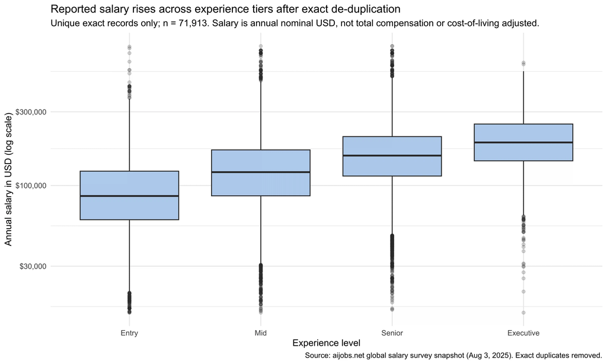

The dataset contained 151,445 supplied compensation records. Removing exact duplicate rows left 71,913 unique records, meaning that 52.5% of supplied rows were repeated copies of an identical record. Because the archive has no respondent ID, employer name, posting ID, or row-level provenance, we cannot determine whether those repeated rows are data duplicates or distinct respondents with identical observed characteristics. We wanted to prevent potentially repeated observations from receiving extra weight, and we want to reduce the risk of overstating the amount of information in the dataset. Therefore, we use the exact de-duplicated dataset ($n = 71,913$) for our primary analysis.

## Missingness and Currency Standardization

Field-level missingness audit across deduplicated records (n = 71,913)

| Variable Name | Missing Values (NA) | Missing Share |
| --- | --- | --- |
| work_year | 0 | 0.0% |
| experience_level | 0 | 0.0% |
| employment_type | 0 | 0.0% |
| job_title | 0 | 0.0% |
| salary | 0 | 0.0% |
| salary_currency | 0 | 0.0% |
| salary_in_usd | 0 | 0.0% |
| employee_residence | 0 | 0.0% |
| remote_ratio | 0 | 0.0% |
| company_location | 0 | 0.0% |
| company_size | 0 | 0.0% |

Top reporting currencies prior to USD normalization

| Currency Code | Record Count | Share of Total |
| --- | --- | --- |
| USD | 65,910 | 91.7% |
| GBP | 2,719 | 3.8% |
| EUR | 2,268 | 3.2% |
| CAD | 570 | 0.8% |
| INR | 137 | 0.2% |

Across all 11 supplied variables in the deduplicated sample ($n = 71,913$), an explicit missingness audit revealed zero missing values (`NA = 0`).

Implied annual exchange conversion consistency (Local Currency to USD)

| Work Year | Currency | Mean Implied FX | Min FX | Max FX |
| --- | --- | --- | --- | --- |
| 2020 | CAD | 0.7459 | 0.7459 | 0.7459 |
| 2020 | EUR | 1.1405 | 1.1404 | 1.1405 |
| 2020 | GBP | 1.2826 | 1.2826 | 1.2826 |
| 2021 | CAD | 0.7976 | 0.7976 | 0.7976 |
| 2021 | EUR | 1.1820 | 1.1820 | 1.1821 |
| 2021 | GBP | 1.3755 | 1.3755 | 1.3755 |
| 2022 | CAD | 0.7681 | 0.7681 | 0.7681 |
| 2022 | EUR | 1.0507 | 1.0506 | 1.0507 |
| 2022 | GBP | 1.2313 | 1.2313 | 1.2313 |
| 2023 | CAD | 0.7409 | 0.7409 | 0.7409 |
| 2023 | EUR | 1.0797 | 1.0796 | 1.0797 |
| 2023 | GBP | 1.2304 | 1.2304 | 1.2304 |
| 2024 | CAD | 0.7692 | 0.7692 | 0.7692 |
| 2024 | EUR | 1.1111 | 1.1111 | 1.1111 |
| 2024 | GBP | 1.2500 | 1.2500 | 1.2500 |
| 2025 | CAD | 0.7143 | 0.7143 | 0.7143 |
| 2025 | EUR | 1.0526 | 1.0526 | 1.0526 |
| 2025 | GBP | 1.2658 | 1.2658 | 1.2658 |

## Years Covered

Distribution of deduplicated compensation records by work year

| Work Year | Record Count (n) | Share |
| --- | --- | --- |
| 2020 | 75 | 0.1% |
| 2021 | 214 | 0.3% |
| 2022 | 1,114 | 1.5% |
| 2023 | 4,538 | 6.3% |
| 2024 | 27,690 | 38.5% |
| 2025 | 38,282 | 53.2% |

The raw dataset spans 2020 through 2025, but density is heavily skewed toward recent years (2024–2025). An important thing to note is that 2025 will not contain a full calendar year of records as the snapshot was made in August.

## Countries

Top 5 geographical concentrations for employees and employers

| Dimension | Country Code | Record Count (n) | Share |
| --- | --- | --- | --- |
| Employee Residence | US | 60,085 | 83.55% |
| Employee Residence | CA | 4,570 | 6.35% |
| Employee Residence | GB | 2,826 | 3.93% |
| Employee Residence | AU | 506 | 0.70% |
| Employee Residence | NL | 398 | 0.55% |
| Company Location | US | 60,147 | 83.64% |
| Company Location | CA | 4,571 | 6.36% |
| Company Location | GB | 2,835 | 3.94% |
| Company Location | AU | 511 | 0.71% |
| Company Location | DE | 400 | 0.56% |

The dataset is heavily dominated by US geographic concentration where 83.55% of respondents reside in the United States, and 83.64% of employing companies are based in the U.S.

## Company size composition

Distribution of records by employing firm size

| Company Size | Record Count (n) | Share |
| --- | --- | --- |
| Large (>250 employees) | 1,588 | 2.2% |
| Medium (50-250 employees) | 70,110 | 97.5% |
| Small (<50 employees) | 215 | 0.3% |

The distribution of company size is heavily dominated by Medium-sized companies (50-250 employees) accounting for 97.5% of all deduplicated observations ($n=70,110$). Large-sized companies (>250 employees) account for 2.2% ($n=1,588$) and Small-sized companies (<50 employees) account for 0.3% ($n=215$).

## Remote-status composition

Distribution of records by remote work model

| Remote Policy | Record Count (n) | Share |
| --- | --- | --- |
| On-Site (0% remote) | 54,081 | 75.2% |
| Hybrid (50% remote) | 327 | 0.5% |
| Fully Remote (100% remote) | 17,505 | 24.3% |

`remote_ratio` only takes three values: 0 (on-site), 50 (hybrid), 100 (fully remote) so it lacks detail regarding mandatory in-office days or flexible hybrid policies. On-site observations dominates the distribution as it accounts for 75.2% of all deduplicated observations.

## Job title composition

Standardized role family categorization logic summary

| Role Family | Record Count (n) | Share of Sample |
| --- | --- | --- |
| Other / unclassified | 27,474 | 38.2% |
| Data Engineering & Architecture | 9,903 | 13.8% |
| Data & BI Analyst | 9,506 | 13.2% |
| Software & Platform Engineering | 8,149 | 11.3% |
| Data Scientist | 7,356 | 10.2% |
| Machine Learning / AI | 6,144 | 8.5% |
| Product & Technical Leadership | 3,381 | 4.7% |

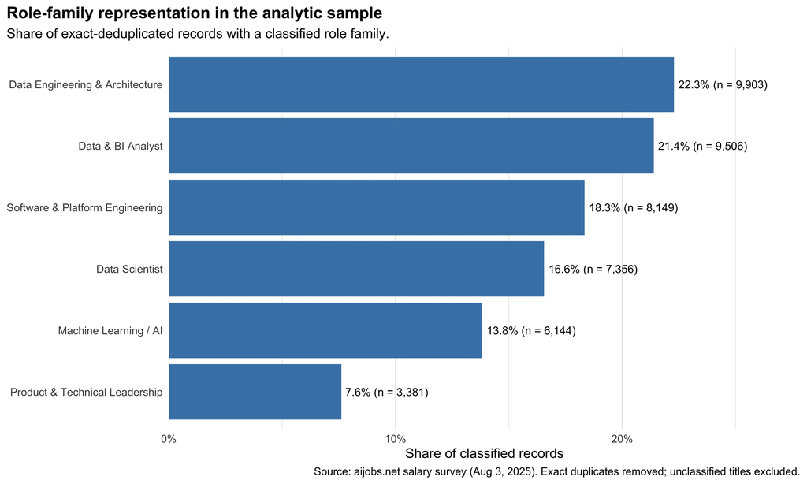

The six explicit role families contain **44,439 of 71,913** exact-deduplicated records (**61.8%**). The remaining **27,474 records (38.2%)** have an unclassified title. We deliberately leave general titles such as Engineer, Manager, Analyst, Developer, Director, and Research Scientist unclassified when the available title alone does not identify a functional specialty; this is preferable to inventing unsupported role labels. The classification therefore supports *comparisons among clearly identified roles*, not conclusions about the entire technology workforce. Unclassified titles remain in analyses that do not use role family; the regression appendix also provides a sensitivity check that retains them as their own category. A future iteration could audit the most frequent unclassified titles and incorporate verified job-description data.

### Audit of unclassified job titles

The most common unclassified titles are listed below to make the classification decision auditable. Some may deserve reassignment only after checking verified job descriptions; an unknown title is not automatically a low-skilled or unrelated role.

Most frequent titles left outside the six specific role families

| Unclassified Job Title | Record Count |
| --- | --- |
| Engineer | 4375 |
| Manager | 3612 |
| Analyst | 2783 |
| Research Scientist | 1381 |
| Associate | 1238 |
| Research Engineer | 887 |
| Consultant | 783 |
| Developer | 715 |
| Data Specialist | 669 |
| Applied Scientist | 561 |
| Architect | 543 |
| Director | 512 |
| Solutions Architect | 436 |
| Site Reliability Engineer | 333 |
| Research Analyst | 321 |

## Cross-border sparsity

Comparison of domestic vs. cross-border employment arrangements

| Geographic Relationship | Record Count (n) | Share |
| --- | --- | --- |
| Cross-Border (Remote International) | 156 | 0.2% |
| Domestic (Same Country) | 71,757 | 99.8% |

Cross-border records (where employee residence is not the same as company location) were too sparse to support robust geographic-arbitrage modeling. Only 156 of 71,913 unique records (0.2%) represent cross-border employment relationships.

## Audit limits

- Removing exact duplicates reduced the dataset from 151,445 to 71,913 records (a 52.5% reduction). Without respondent or posting identifiers, we cannot confirm whether the repeats were data duplication or distinct people with identical observed value.
- The archive has no employer name, posting ID, observation date, or row-level source to verify individual entries.
- Record counts represent survey submissions, not employer demand or job-opening counts.
- `salary_in_usd` reflects nominal base salary only, not total compensation, and is unadjusted for inflation or local purchasing power.
- Remote status is limited to three discrete values (0, 50, 100) without detail on hybrid policies.
- Employee residence and employer location are recorded at the country level, omitting city- or regional-level variation.
- Cross-border employer/employee pairs (0.22% of unique records) are too sparse for reliable comparison.
- All observed differences across roles, experience levels, and company sizes are descriptive associations only.
- The data source also has the majority of salary observations in 2024 to 2025. This means that there are limited time series analysis opportunities.

# 2. Compensation landscape

**From data quality to an actionable benchmark.** Because the records are self-reported, strongly concentrated in a subset of years and employer sizes, and contain unusually high salaries, medians and interquartile ranges offer a more defensible first comparison than arithmetic means. We first establish which role families sit toward the upper end of the reported salary distribution, then investigate whether experience tier and work arrangement change that comparison.

Coverage and compensation summaries under the final role-family rules (deduplicated sample)

| Role Family | Count (n) | Share | Unique Titles | Median Salary | 25th Percentile | 75th Percentile |
| --- | --- | --- | --- | --- | --- | --- |
| Machine Learning / AI | 6,144 | 8.5% | 40 | $170,042 | $125,375 | $226,000 |
| Product & Technical Leadership | 3,381 | 4.7% | 17 | $163,925 | $114,500 | $224,000 |
| Software & Platform Engineering | 8,149 | 11.3% | 23 | $159,000 | $117,000 | $210,985 |
| Data Scientist | 7,356 | 10.2% | 14 | $142,000 | $100,000 | $191,500 |
| Data Engineering & Architecture | 9,903 | 13.8% | 27 | $139,400 | $99,800 | $186,000 |
| Other / unclassified | 27,474 | 38.2% | 255 | $137,100 | $94,900 | $190,000 |
| Data & BI Analyst | 9,506 | 13.2% | 46 | $100,000 | $72,500 | $136,000 |

## The Compensation Distribution & Outlier Dashboard

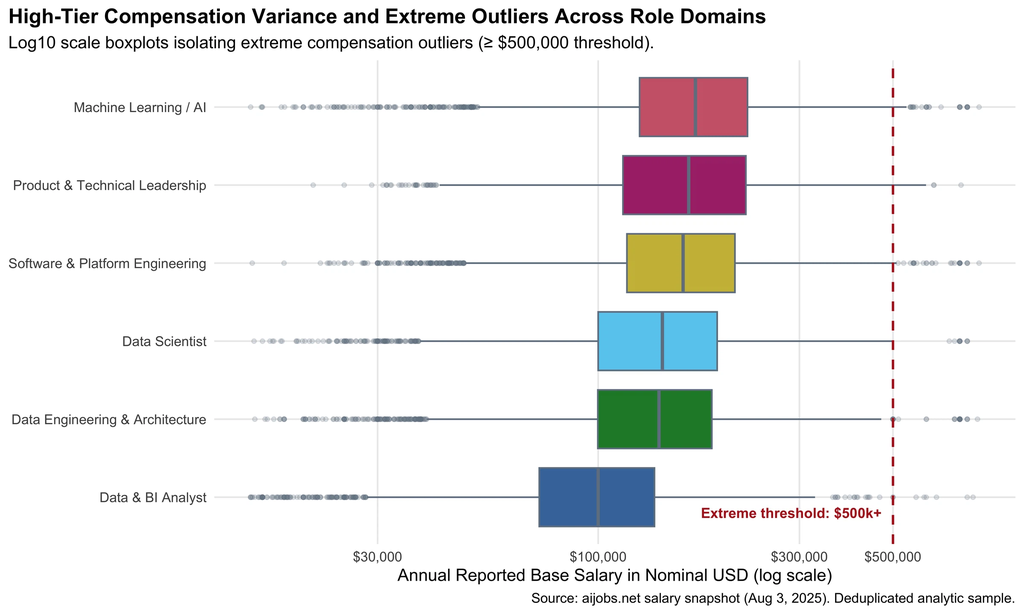

Across the deduplicated sample ($n = 71,913$), reported base salaries displayed right-skewness and extreme high-end outliers across all technical categories. Therefore, we decided to use medians and interquartile ranges (IQR) as the primary metrics for central tendency and spread.

Machine Learning / AI displayed the highest median reported salary at $170,042 ($n = 6,144$, 8.5% of sample; IQR: $125,375–$226,000). Product & Technical Leadership at $163,925 ( $n = 3,381$, 4.7%; IQR: $114,500–$224,000) and Software & Platform Engineering at $159,000 ( $n = 8,149$, 11.3%; IQR: $117,000–$210,985) follow closely as top-tier compensation drivers. Data Scientist roles report a median salary of $142,000 ($n = 7,356$, 10.2%; IQR: $100,000–$191,500), closely followed by Data Engineering & Architecture at $139,400 ($n = 9,903$, 13.8%; IQR: $99,800–$186,000). Data & BI Analyst records the lowest compensation baseline among defined role families at $100,000 ($n = 9,506$, 13.2%; IQR: $72,500–$136,000), with a difference of $70,042 from the ML/AI median (a 41.2% lower baseline).

# 3. Career and market signals

## Client Question 1: How do compensation trajectories differ across career levels, and what is the financial return when progressing through tiers?

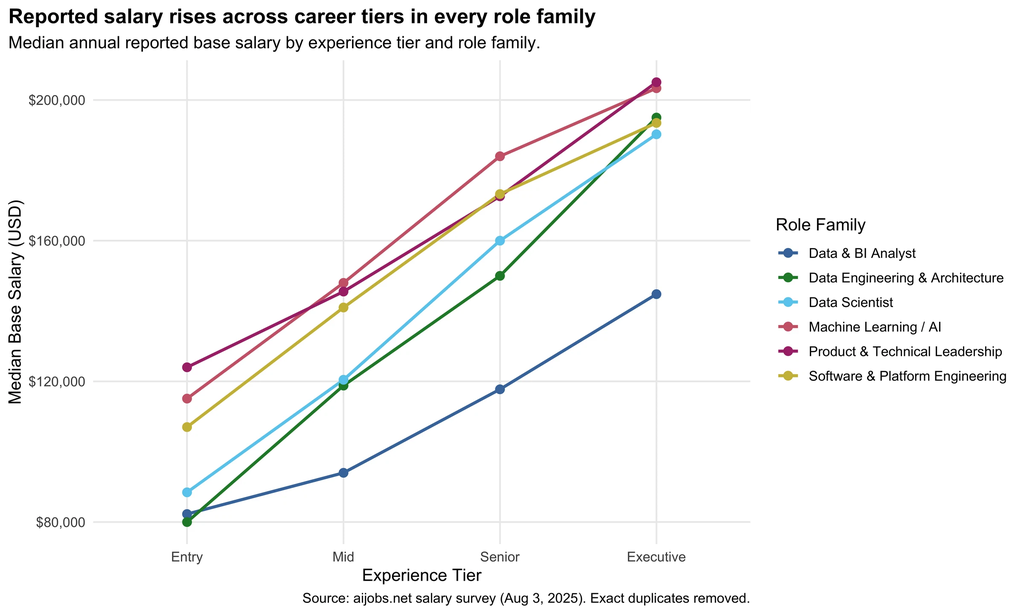

The line chart compares **separate groups of workers**, not the compensation changes of the same people over time. Reported medians increase with experience tier across all six classified role families, and senior/executive roles are especially relevant for a specialist search practice. However, the gaps should not be described as actual promotion raises, expected career returns, or firm-specific offer budgets. The priority-role benchmark table in Section 4 supplies the corresponding sample sizes and exact SE/EX medians.

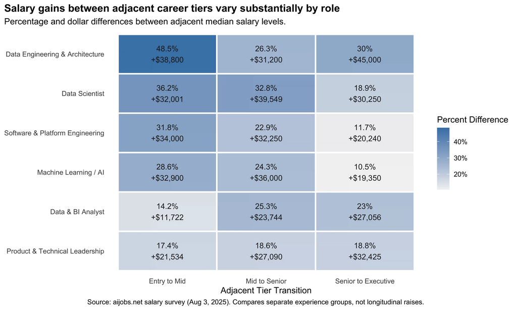

### Key findings

Differences between experience groups vary by role family: the largest *percentage* step-up need not belong to the field with the highest *absolute* executive pay. Thus we should choose search priorities using both observed senior/executive compensation levels and evidence of client-specific business need, rather than using the heatmap to infer promotion budgets. This motivates the next question: whether expanding the sourcing geography would necessarily require a different pay band.

## Client Question 2: Is there a measurable remote work premium or remote penalty?

Unadjusted salary statistics by remote work arrangement

| Remote Status | Count (n) | Share | Median Salary | 25th Percentile | 75th Percentile |
| --- | --- | --- | --- | --- | --- |
| Fully remote | 17,505 | 24.3% | $140,000 | $100,000 | $187,200 |
| Hybrid | 327 | 0.5% | $69,999 | $43,468 | $100,208 |
| On-site | 54,081 | 75.2% | $138,300 | $95,300 | $192,890 |

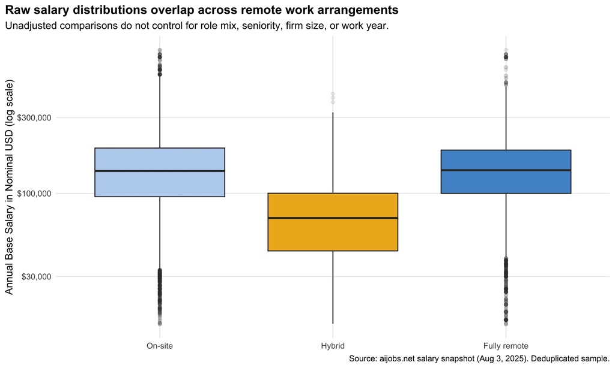

The plot shows a side-by-side boxplot display and accompanying summary table comparing reported annual base salary distributions in nominal USD (on a log scale) across three remote work categories: On-site (0%), Hybrid (50%), and Fully Remote (100%). Fully Remote roles report an unadjusted median base salary of $\$140,000$ (IQR: $\$100,000$–$\$187,200$), closely matching On-site roles at $\$138,300$ (IQR: $\$95,300$–$\$192,890$). Hybrid roles represent a sparse, lower-paid subset (0.5% of records, $\$69,999$ median). Raw comparisons fail to show a clear difference between the distributions of on-site and fully remote salaries but justifies the need for multiple regression.

### Regression Analysis

To estimate the conditional association between remote status and reported base salary, we fit a log-linear model controlling for role family, experience level, company size, and work year. We take the natural log of salaries in order to satisfy linear assumptions, as the salary distribution appears severely right-skewed and heteroskedastic (see Appendix). Our main covariate of interest is remote status as we want to determine whether remote employees face a compensation premium. The model controls for the other potential confounding variables including role family controlling for pay variation across different fields, experience level controlling for difference in pay depending on seniority, company size controlling for wage premiums based on small, medium, and large companies, and lastly work year controlling for changing environmental factors over time. The primary model compares on-site with fully remote records within six explicitly classified role families. We initially set aside hybrid records because only 327 of the 71,913 deduplicated records are coded as hybrid, and the main question is the on-site versus fully remote contrast. This restriction makes the coefficient easier to interpret but may introduce selection bias. Below, a sensitivity model includes hybrid workers and the unclassified role family rather than assuming that their exclusion has no effect. Categorical predictors are encoded with dummy variables.

Log-linear salary regression model coefficients (selected key variables)

| Term | Estimate (log) | Implied % Change | Std. Error | p-value |
| --- | --- | --- | --- | --- |
| remote_statusFully remote | -0.0073 | -0.7% | 0.0050 | 0.141 |
| role_familyData Engineering & Architecture | 0.1969 | 21.8% | 0.0069 | < 0.001 |
| role_familyData Scientist | 0.2467 | 28.0% | 0.0074 | < 0.001 |
| role_familyMachine Learning / AI | 0.4086 | 50.5% | 0.0078 | < 0.001 |
| role_familyProduct & Technical Leadership | 0.3659 | 44.2% | 0.0095 | < 0.001 |
| role_familySoftware & Platform Engineering | 0.3491 | 41.8% | 0.0072 | < 0.001 |
| experience_levelMid | 0.2228 | 25.0% | 0.0080 | < 0.001 |
| experience_levelSenior | 0.4508 | 57.0% | 0.0076 | < 0.001 |
| experience_levelExecutive | 0.6439 | 90.4% | 0.0139 | < 0.001 |
| company_sizeMedium | 0.4940 | 63.9% | 0.0398 | < 0.001 |

Holding role family, experience tier, company size, and work year constant, fully remote status exhibits an estimated coefficient of $\hat{\beta} = -0.0073$, corresponding to an implied salary difference of -0.7% compared to on-site roles. This coefficient is statistically insignificant ($t = -1.47, p = 0.141$). The 95% confidence interval for the remote status coefficient ranges from -1.69% to +0.24%. Because zero is included in this interval and the $p$-value exceeds $\alpha = 0.05$, we fail to reject the null hypothesis of equal pay. By contrast, experience tier and role family show much larger estimated conditional pay associations. In the fitted model, Executive records have an estimated **+90.4%** difference ($\hat{\beta} = 0.6439, p < 0.001$) relative to Entry-level records, while Machine Learning / AI has a **+50.5%** estimated difference ($\hat{\beta} = 0.4086, p < 0.001$) over the Data & BI Analyst baseline.

### Sensitivity check: hybrid workers and unclassified roles

The instructor’s feedback raises a reasonable concern: excluding hybrid workers and generic job titles could change the adjusted association. We therefore compare the original two-group model with a second model that retains all three remote categories and the unclassified role family. A third model restricts the original comparison to US-resident workers at US-based employers, closer to the proposed Walmart use case. In all models, *On-site* remains the reference group; the reported coefficient is the fully remote versus on-site contrast.

Sensitivity of adjusted fully remote versus on-site salary estimate

| Model | N | Adjusted remote difference | 95% CI, low | 95% CI, high |
| --- | --- | --- | --- | --- |
| Classified, on-site vs fully remote | 44,171 | -0.7% | -1.7% | 0.2% |
| All roles and all remote categories | 71,913 | -1.9% | -2.7% | -1.1% |
| US-to-US, classified, on-site vs fully remote | 36,480 | -2.1% | -3.0% | -1.1% |

### Key findings

In the primary specification, the fully remote coefficient is small (−0.7%) and its confidence interval includes zero. This does **not** prove that salaries are equivalent or that remote recruiting requires no additional compensation. The sensitivity table shows whether the estimate changes when omitted groups are retained. Any nationwide sourcing recommendation must also consider occupation, candidate location, the position’s permitted work arrangements, and Walmart’s published location-specific compensation bands.

## Client Question 3: Where are salaries growing, and which specific roles and company sizes present the best opportunities for executive recruiting?

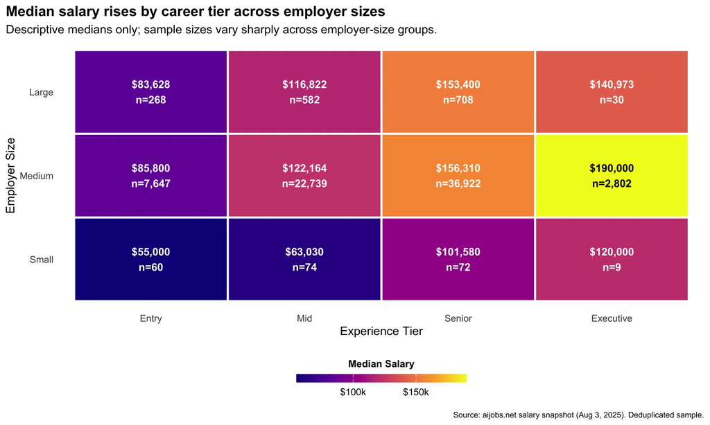

The heatmap compares reported base-salary medians by company-size category and experience tier. Medium-sized employers show a higher executive median ($190,000) than large employers ($140,973) in **this sample**, but 97.5% of the deduplicated observations come from the medium category and just 2.2% from the large category. Consequently, these differences may reflect uneven coverage, occupation mix, or other unobserved variables. The chart cannot establish that mid-sized companies have greater willingness to pay, or that these are suitable compensation bands for Walmart, which belongs to a much larger and different employer group. Cell labels now show the relevant n.

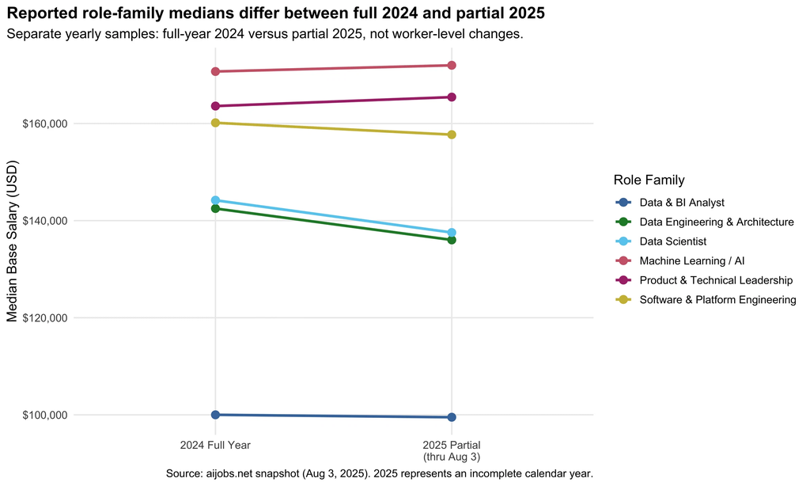

This chart compares *two groups of records*—all of 2024 and only the portion of 2025 present by August 3. It is not a longitudinal panel of workers or employers. Product & Technical Leadership has a higher reported 2025 median than in 2024, whereas several other families are lower, but shifts in occupation, geography, company size, or response composition could explain these patterns. They should therefore be presented as tentative survey benchmarks, not definitive evidence of salary inflation, market-wide cooling, or accelerating hiring demand.

### Key findings

The company-size and year comparisons are useful for generating hypotheses, but their uneven sample composition prevents strong claims about the most profitable clients or fastest-growing hiring markets. To choose a particular client, we need evidence outside the salary archive: documented technology priorities, recognizable senior openings, and location-specific posted compensation. We now apply that standard to a potential Walmart Global Tech pitch.

# 4. Recruiting Playbook

## Target Employer: Why Walmart Global Tech?

**Why this client, rather than a generic large corporation?** Walmart is investing in technology-intensive capabilities with direct links to our salary analysis: AI, software platforms, supply-chain systems, and e-commerce. Its [FY2026 Form 10-K](https://stock.walmart.com/sec-filings/all-sec-filings/content/0000104169-26-000055/wmt-20260131.htm) reports $16.468 billion of U.S. capital expenditures in a *combined* category comprising supply chain, customer-facing initiatives, technology, and other items. This supports the scale of the operational investment, but is **not** a stand-alone technology budget or evidence of a specific executive-search contract.

**What indicates potential searches?** The following Walmart career postings were consulted in October 2026, after the 2025 salary snapshot. Walmart’s publicly advertised [Group Director, Software Engineering — Applied AI](https://careers.walmart.com/us/en/jobs/R-2599274) role describes leadership across foundational models, machine-learning teams, and commercial applications such as search, advertising, and supply-chain forecasting. The advertised annual **base-pay bands** are $195,000–$370,000 in Bentonville and $254,000–$481,000 in Sunnyvale. A separate [Director, Software Engineering](https://careers.walmart.com/us/en/jobs/R-2640730) posting lists $130,000–$260,000 in Bentonville and $169,000–$338,000 in Sunnyvale. These are employer-posted ranges, **not** observed pay, hire counts, or measured recruiting difficulty; listings may change. They demonstrate that Walmart recruits for the kinds of senior, location-sensitive roles relevant to Libeccio’s proposed specialty.

**Why might an outside search firm add value despite Walmart’s internal recruiting organization?** We should not argue that Walmart’s recruiters lack executive-search skills without evidence. A more defensible proposition is *complementary specialization*: Libeccio could undertake one agreed-upon hard-to-source senior AI or platform leadership search, research passive candidates across technology markets, compare location-specific compensation expectations, and deliver a qualified shortlist. The Bentonville-versus-Sunnyvale pay bands highlight a practical challenge for offer strategy; they do **not** imply Walmart permits every role to be fully remote or that a national candidate search will preserve the same salary budget.

**What would earn the business?** Start with a limited-scope pilot, subject to confirmation that Walmart has an unmet recruiting need and is willing to use an external firm. Define the target role, work location, compensation package, passive-candidate profile, outreach coverage, and measurable shortlist or time-to-fill outcomes before negotiating an ongoing relationship. Our salary study helps frame questions for this pitch, while the Walmart-specific sources establish why the prospect deserves further consideration. It does not establish that Walmart has agreed to engage Libeccio or needs an external recruiter.

## Priority Roles and Experience Tiers

Our proposed **primary specialty** is senior and executive ML/AI and software-platform leadership. These are related capabilities rather than three unrelated recruiting businesses: applied AI requires both model-building expertise and the engineering platforms needed to operate systems reliably at scale. Product & Technical Leadership is an adjacent, selective specialty where Walmart’s specific open roles call for it. Data Engineering & Architecture is a supporting talent pipeline worth evaluating because of its relevance to platform and supply-chain data systems.

The archive’s overall medians are $170,042 for Machine Learning / AI, $159,000 for Software & Platform Engineering, and $163,925 for Product & Technical Leadership. More relevant to the proposed search niche, the **executive-tier** median within these groups is $203,350, $193,490, and $205,050 respectively, with sample sizes of 152, 187, and 316. These are descriptive medians across the full dataset, not exact estimates of what Walmart should offer. Employer location, responsibility, equity, and bonuses must be evaluated independently.

## Salary Benchmarks

These metrics summarize annual base salaries across Libeccio’s target roles.

Directional Compensation Benchmarks for Target Sourcing Priorities (Source: aijobs.net frozen snapshot, Aug. 3, 2025; deduplicated N = 71,913)

| Role Family | Experience Tier | Sample Size (n) | Median Base Salary | 25th Percentile | 75th Percentile |
| --- | --- | --- | --- | --- | --- |
| Machine Learning / AI | Senior | 3,950 | $184,000 | $139,251 | $239,550 |
| Machine Learning / AI | Executive | 152 | $203,350 | $172,575 | $256,962 |
| Product & Technical Leadership | Senior | 1,454 | $172,625 | $130,000 | $230,000 |
| Product & Technical Leadership | Executive | 316 | $205,050 | $160,000 | $270,000 |
| Software & Platform Engineering | Senior | 4,798 | $173,250 | $131,000 | $223,900 |
| Software & Platform Engineering | Executive | 187 | $193,490 | $151,025 | $252,000 |

In the generated benchmark table, median Senior-tier base salaries range from **$172,625 to $184,000**, and median Executive-tier base salaries range from **$193,490 to $205,050** across the three proposed families. The subgroup sample sizes, especially in the Executive tier, should accompany these figures. These are directional survey medians, not evidence of Walmart’s actual offers, total compensation, or recruiter placement fees; Walmart’s published location-specific job bands offer an additional, employer-specific reference.

## Search Strategy

Libeccio should **offer Walmart a tightly scoped pilot search** focused on one senior AI / machine-learning or platform-engineering leadership position. Begin by confirming the role’s business owner, location and work-arrangement requirements, essential skills, reporting scope, compensation structure, and whether outside sourcing is desired.

The immediate deliverable would be a market map of relevant talent, compensation comparisons segmented by geography and seniority, and a shortlist of qualified candidates who meet the agreed criteria. A successful pilot could create an opening for adjacent product or data engineering searches, but longer-term client value and repeat business should be framed as goals rather than guaranteed outcomes.

Use the **survey’s role/experience medians to set initial research questions**, and Walmart’s advertised bands and validated bonus/equity benchmarks to determine actual offer competitiveness. Reject claims about automatic remote-pay savings, fixed placement fee margins, or which roles are definitively most profitable: those require information that the current dataset does not contain.

## Next Data Source

The compensation archive contains annual nominal base salary but not restricted stock units, annual bonuses, sign-on awards, or other forms of compensation. A next-stage offer study should obtain a consistent source of total-compensation benchmarks (for example, Pave, Levels.fyi, or an employer-sponsored compensation survey), verify the methodology and licensing terms, and combine it with role- and location-specific Walmart salary bands. Only then could Libeccio build credible offer scenarios or negotiate a placement-fee structure grounded in the expected scope of the search.

**Bottom line:** the evidence supports a targeted *prospective-client pitch* and an AI/platform leadership search hypothesis—not a claim that Walmart has a recruiting deficiency, that remote pay is universally identical, or that the archive measures hiring demand.

# Appendix

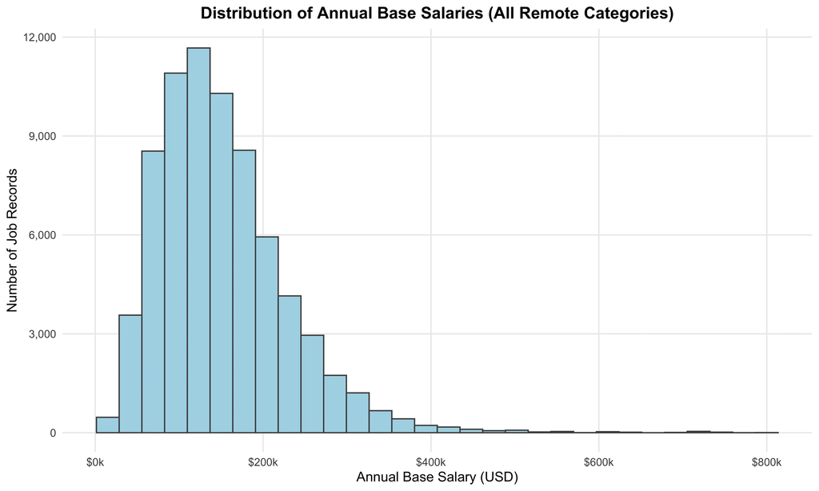

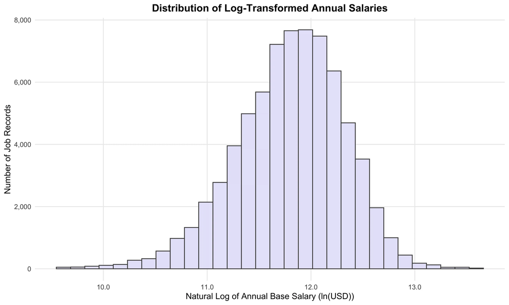

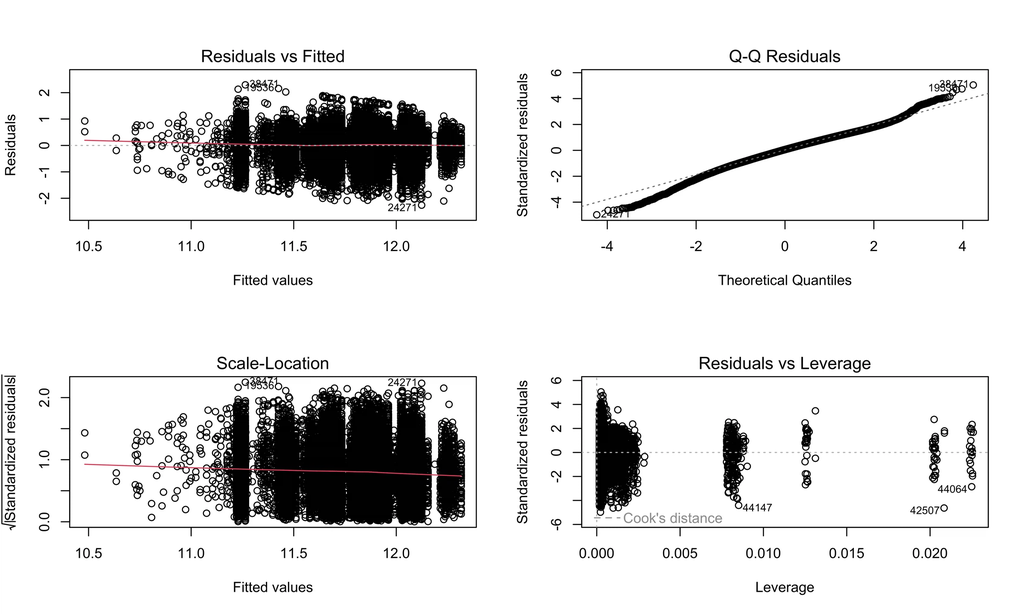

```
Analysis of Variance Table

Model 1: log(salary_in_usd) ~ role_family + experience_level + company_size +
    factor(work_year)
Model 2: log(salary_in_usd) ~ remote_status + role_family + experience_level +
    company_size + work_year
  Res.Df    RSS Df Sum of Sq      F Pr(>F)
1  44155 9120.2
2  44154 9119.7  1   0.44685 2.1635 0.1413
```

```
remote_statusFully remote
             -0.007290059
```

```
                                2.5 %      97.5 %
remote_statusFully remote -0.01692192 0.002436168
```

## Reproducibility and analytical decisions

- **Source data:** [Course-hosted aijobs.net salary CSV](https://stat.cmu.edu/~sgallagh/courses/mads-fall-2026/datavis-36613/data/salaries.csv.gz); reported salary snapshot through August 3, 2025. Rechecked when the report is rendered: 2026-10-25. The remote host could change; save a permitted versioned data copy or checksum for archival reproducibility.
- **Unit:** One salary record in the supplied archive. This is neither a verified unique employee nor a posted job opening.
- **Cleaning:** `distinct()` across all 11 supplied columns removes exact duplicate records (151,445 to 71,913); it cannot identify unique people. Role-family assignment uses ordered title-based keyword rules shown in the source code; unknown roles are not silently imputed.
- **Salary measure:** `salary_in_usd`, nominal annual base salary, not cost-of-living adjusted and not total pay. Reported local-currency conversions are checked descriptively, not re-estimated.
- **Inference:** The main remote model compares on-site and fully remote classified records; the sensitivity model retains hybrid and unclassified rows. Neither model identifies a causal effect or controls for city-level geography.
- **Limitations:** Large-company, hybrid, cross-border, executive subgroups, and 2025 partial-year comparisons require special caution. External Walmart descriptions are sourced separately from the salary survey and must be revalidated when job postings change.